# Untitled

Golnar Babakhani Teimouri

May 19, 2018

# Congress tweets after shooting

```
## # A tibble: 54,333 x 3
##    word1     word2           n
##    <chr>     <chr>       <int>
##  1 health    care          154
##  2 gun       violence      149
##  3 town      hall          148
##  4 law       enforcement   142
##  5 house     floor         129
##  6 op        ed             96
##  7 house     passed         88
##  8 president obama          82
##  9 navy      yard           79
## 10 happy     birthday       77
## # ... with 54,323 more rows
```

```
## # A tibble: 73,798 x 8
##    Date  Time  R_or_D Before_or_After screen_name hashtags Nominate_dim1
##    <chr> <tim> <chr>  <chr>           <chr>       <chr>            <dbl>
##  1 1/8/… 00:05 D      After           GabbyGiffo… <NA>            -0.11
##  2 1/8/… 00:05 D      After           GabbyGiffo… <NA>            -0.11
##  3 1/8/… 00:05 D      After           GabbyGiffo… <NA>            -0.11
##  4 1/8/… 00:05 D      After           GabbyGiffo… <NA>            -0.11
##  5 1/8/… 01:53 D      After           SilvestreR… <NA>            -0.321
##  6 1/8/… 01:53 D      After           SilvestreR… <NA>            -0.321
##  7 1/8/… 01:53 D      After           SilvestreR… <NA>            -0.321
##  8 1/8/… 01:53 D      After           SilvestreR… <NA>            -0.321
##  9 1/8/… 01:53 D      After           SilvestreR… <NA>            -0.321
## 10 1/8/… 04:42 D      After           GabbyGiffo… <NA>            -0.11
## # ... with 73,788 more rows, and 1 more variable: bigram <chr>
```

Table 1. Highest Tfidf Bigrams in Tweets by Party 48 Hours After Shooting

| Republican or Democrat | Term | n | tf | idf | tf_idf |
| --- | --- | --- | --- | --- | --- |
| D | gun violence | 149 | 0.0050074 | 0.6931472 | 0.0034709 |
| D | askdems disarmhate | 36 | 0.0012098 | 0.6931472 | 0.0008386 |
| R | pro life | 40 | 0.0009082 | 0.6931472 | 0.0006295 |
| R | protect children | 39 | 0.0008855 | 0.6931472 | 0.0006138 |
| R | life bill | 37 | 0.0008401 | 0.6931472 | 0.0005823 |
| D | lgbt community | 21 | 0.0007057 | 0.6931472 | 0.0004892 |
| R | obama admin | 30 | 0.0006812 | 0.6931472 | 0.0004721 |
| D | chisummit cbctalks | 20 | 0.0006721 | 0.6931472 | 0.0004659 |
| D | mass shootings | 20 | 0.0006721 | 0.6931472 | 0.0004659 |
| D | earth day | 19 | 0.0006385 | 0.6931472 | 0.0004426 |
| D | minimum wage | 17 | 0.0005713 | 0.6931472 | 0.0003960 |
| R | supports pro | 24 | 0.0005449 | 0.6931472 | 0.0003777 |
| D | senator inouye | 15 | 0.0005041 | 0.6931472 | 0.0003494 |
| R | pa11 nepa | 22 | 0.0004995 | 0.6931472 | 0.0003462 |
| D | altonsterling philandocastile | 14 | 0.0004705 | 0.6931472 | 0.0003261 |
| R | gopoversight hearing | 19 | 0.0004314 | 0.6931472 | 0.0002990 |
| R | 40 hour | 18 | 0.0004087 | 0.6931472 | 0.0002833 |
| R | god bless | 18 | 0.0004087 | 0.6931472 | 0.0002833 |
| R | medicare advantage | 18 | 0.0004087 | 0.6931472 | 0.0002833 |
| R | ne02 omaha | 18 | 0.0004087 | 0.6931472 | 0.0002833 |

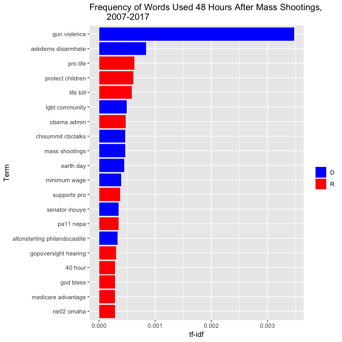

# Logs Ratio for after shootings

```
## # A tibble: 54,333 x 4
##    bigram                    D         R logratio
##    <chr>                 <dbl>     <dbl>    <dbl>
##  1 families affected 0.000214  0.000213  -0.00276
##  2 protect americans 0.0000714 0.0000712 -0.00276
##  3 sandy hook        0.0000714 0.0000712 -0.00276
##  4 2 2               0.000202  0.000203   0.00561
##  5 bipartisan bill   0.000202  0.000203   0.00561
##  6 middle school     0.000155  0.000152  -0.0138
##  7 1 2               0.000250  0.000254   0.0174
##  8 care reform       0.0000832 0.0000813 -0.0234
##  9 committee hearing 0.000166  0.000163  -0.0234
## 10 families friends  0.0000832 0.0000813 -0.0234
## # ... with 54,323 more rows
```

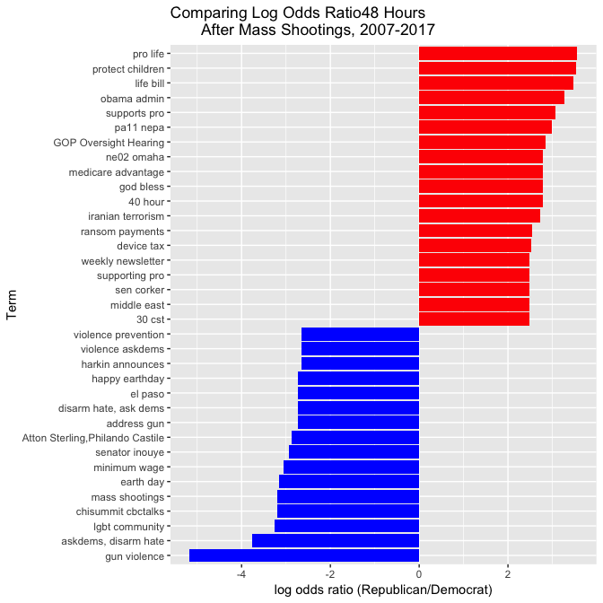

# Comparing words frequency by plotting(after shooting)

```
## # A tibble: 56,844 x 5
## # Groups:   R_or_D [2]
##    R_or_D bigram              n total    freq
##    <chr>  <chr>           <int> <int>   <dbl>
##  1 D      gun violence      149 29756 0.00501
##  2 R      law enforcement   103 44042 0.00234
##  3 R      health care        96 44042 0.00218
##  4 R      house passed       77 44042 0.00175
##  5 R      house floor        76 44042 0.00173
##  6 D      town hall          75 29756 0.00252
##  7 R      town hall          73 44042 0.00166
##  8 R      op ed              68 44042 0.00154
##  9 R      president obama    62 44042 0.00141
## 10 R      watch live         60 44042 0.00136
## # ... with 56,834 more rows
```

```
## # A tibble: 54,333 x 3
##    bigram              D         R
##    <chr>           <dbl>     <dbl>
##  1 1 15        0.0000336 0.0000227
##  2 1 15pm      0.0000336 0.0000227
##  3 1 40        0.0000336 0.0000227
##  4 1 45        0.0000336 0.0000227
##  5 1.3 billion 0.0000336 0.0000227
##  6 1.9 million 0.0000336 0.0000227
##  7 10 10       0.0000336 0.0000227
##  8 100 million 0.0000336 0.0000227
##  9 100 people  0.0000336 0.0000227
## 10 100 rating  0.0000336 0.0000227
## # ... with 54,323 more rows
```

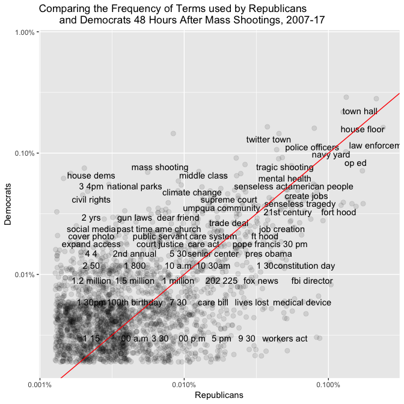

# Congress tweets before shootings

```
## # A tibble: 104,804 x 2
##    word          n
##    <fct>     <int>
##  1 of the      720
##  2 on the      555
##  3 in the      524
##  4 to the      494
##  5 the house   333
##  6 for the     327
##  7 at the      275
##  8 thank you   236
##  9 will be     216
## 10 proud to    207
## # ... with 104,794 more rows
```

```
## # A tibble: 38,511 x 3
##    word1     word2        n
##    <chr>     <chr>    <int>
##  1 health    care       111
##  2 house     floor      111
##  3 town      hall        78
##  4 watch     live        74
##  5 op        ed          72
##  6 middle    class       70
##  7 american  people      63
##  8 national  security    59
##  9 happy     birthday    56
## 10 president obama       47
## # ... with 38,501 more rows
```

```
## # A tibble: 49,635 x 8
##    Date  Time  R_or_D Before_or_After screen_name hashtags Nominate_dim1
##    <chr> <tim> <chr>  <chr>           <chr>       <chr>            <dbl>
##  1 1/10… 00:02 D      Before          RepVisclos… <NA>            -0.402
##  2 1/10… 00:02 D      Before          RepVisclos… <NA>            -0.402
##  3 1/10… 00:02 D      Before          RepVisclos… <NA>            -0.402
##  4 1/10… 00:02 D      Before          RepVisclos… <NA>            -0.402
##  5 1/10… 00:59 R      Before          RepKayGran… <NA>             0.392
##  6 1/10… 00:59 R      Before          RepKayGran… <NA>             0.392
##  7 1/10… 00:59 R      Before          RepKayGran… <NA>             0.392
##  8 1/10… 03:39 R      Before          DevinNunes  <NA>             0.448
##  9 1/10… 03:39 R      Before          DevinNunes  <NA>             0.448
## 10 1/10… 03:39 R      Before          DevinNunes  <NA>             0.448
## # ... with 49,625 more rows, and 1 more variable: bigram <chr>
```

Table 1. Highest Tfidf Bigrams in Tweets by Party 48 hours Before Shooting

| Republican or Democrat | Term | n | tf | idf | tf_idf |
| --- | --- | --- | --- | --- | --- |
| D | gun violence | 26 | 0.0013762 | 0.6931472 | 0.0009539 |
| D | senator inouye | 15 | 0.0007940 | 0.6931472 | 0.0005503 |
| R | veterans deserve | 24 | 0.0007807 | 0.6931472 | 0.0005411 |
| D | equal pay | 14 | 0.0007411 | 0.6931472 | 0.0005137 |
| D | class tax | 12 | 0.0006352 | 0.6931472 | 0.0004403 |
| D | class security | 11 | 0.0005823 | 0.6931472 | 0.0004036 |
| R | tax reform | 17 | 0.0005530 | 0.6931472 | 0.0003833 |
| D | americans makeitinamerica | 10 | 0.0005293 | 0.6931472 | 0.0003669 |
| D | disarmhate lightingtheway | 10 | 0.0005293 | 0.6931472 | 0.0003669 |
| D | student debt | 10 | 0.0005293 | 0.6931472 | 0.0003669 |
| R | floor speech | 16 | 0.0005204 | 0.6931472 | 0.0003607 |
| D | 9 hawaii | 8 | 0.0004235 | 0.6931472 | 0.0002935 |
| D | critical support | 8 | 0.0004235 | 0.6931472 | 0.0002935 |
| D | dotherightthing extend | 8 | 0.0004235 | 0.6931472 | 0.0002935 |
| D | innovation job | 8 | 0.0004235 | 0.6931472 | 0.0002935 |
| D | paycheck fairness | 8 | 0.0004235 | 0.6931472 | 0.0002935 |
| R | sen collins | 13 | 0.0004229 | 0.6931472 | 0.0002931 |
| R | care bill | 12 | 0.0003903 | 0.6931472 | 0.0002706 |
| R | sanctions relief | 12 | 0.0003903 | 0.6931472 | 0.0002706 |
| R | tax hike | 12 | 0.0003903 | 0.6931472 | 0.0002706 |

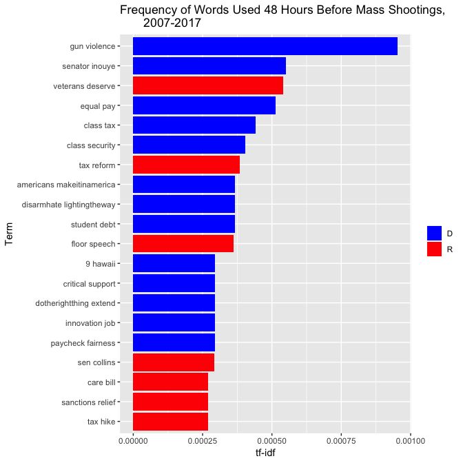

#Logs Ratio for before shooting

```
## # A tibble: 38,511 x 4
##    bigram                     D         R logratio
##    <chr>                  <dbl>     <dbl>    <dbl>
##  1 1 million          0.0000871 0.0000866 -0.00536
##  2 7 30               0.0000871 0.0000866 -0.00536
##  3 save lives         0.0000871 0.0000866 -0.00536
##  4 step forward       0.0000871 0.0000866 -0.00536
##  5 30 pm              0.000105  0.000101  -0.0335
##  6 american flag      0.000105  0.000101  -0.0335
##  7 gabrielle giffords 0.000105  0.000101  -0.0335
##  8 6 30               0.0000697 0.0000722  0.0355
##  9 appropriations act 0.0000697 0.0000722  0.0355
## 10 beautiful day      0.0000697 0.0000722  0.0355
## # ... with 38,501 more rows
```

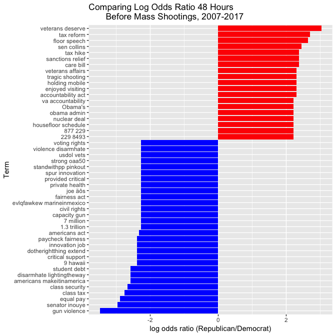

#Comparing all graphs

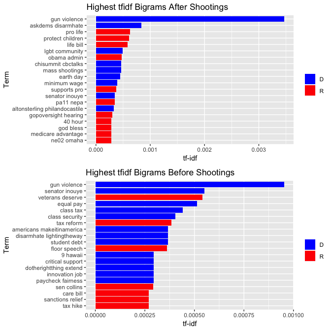

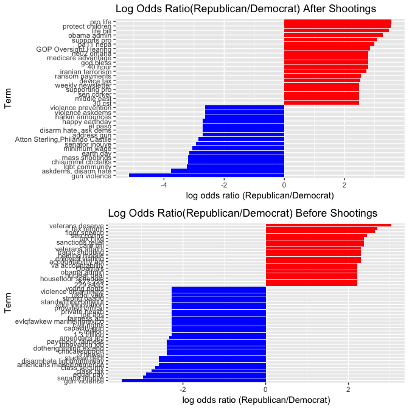

# Joining before and after shooting dataframes

```
## # A tibble: 87,296 x 3
##    word1     word2           n
##    <chr>     <chr>       <int>
##  1 health    care          265
##  2 house     floor         240
##  3 town      hall          226
##  4 gun       violence      175
##  5 op        ed            168
##  6 law       enforcement   161
##  7 watch     live          144
##  8 happy     birthday      133
##  9 president obama         129
## 10 house     passed        126
## # ... with 87,286 more rows
```

```
## # A tibble: 123,408 x 8
##    Date  Time  R_or_D Before_or_After screen_name hashtags Nominate_dim1
##    <chr> <tim> <chr>  <chr>           <chr>       <chr>            <dbl>
##  1 1/10… 00:02 D      Before          RepVisclos… <NA>            -0.402
##  2 1/10… 00:02 D      Before          RepVisclos… <NA>            -0.402
##  3 1/10… 00:02 D      Before          RepVisclos… <NA>            -0.402
##  4 1/10… 00:02 D      Before          RepVisclos… <NA>            -0.402
##  5 1/10… 00:59 R      Before          RepKayGran… <NA>             0.392
##  6 1/10… 00:59 R      Before          RepKayGran… <NA>             0.392
##  7 1/10… 00:59 R      Before          RepKayGran… <NA>             0.392
##  8 1/10… 03:39 R      Before          DevinNunes  <NA>             0.448
##  9 1/10… 03:39 R      Before          DevinNunes  <NA>             0.448
## 10 1/10… 03:39 R      Before          DevinNunes  <NA>             0.448
## # ... with 123,398 more rows, and 1 more variable: bigram <chr>
```

# Words over time

```
## # A tibble: 910 x 6
##    time_floor          R_or_D bigram            count time_total word_total
##    <dttm>              <chr>  <chr>             <int>      <int>      <int>
##  1 2009-01-01 00:00:00 D      30 pm                 1        596         43
##  2 2009-01-01 00:00:00 D      american people       1        596        120
##  3 2009-01-01 00:00:00 D      capitol hill          1        596         45
##  4 2009-01-01 00:00:00 D      committee hearing     1        596         36
##  5 2009-01-01 00:00:00 D      fort hood             1        596         63
##  6 2009-01-01 00:00:00 D      health care           7        596        265
##  7 2009-01-01 00:00:00 D      health insurance      2        596         41
##  8 2009-01-01 00:00:00 D      house floor           2        596        240
##  9 2009-01-01 00:00:00 D      listen live           4        596         72
## 10 2009-01-01 00:00:00 D      op ed                 2        596        168
## # ... with 900 more rows
```

```
## # A tibble: 200 x 3
##    R_or_D bigram            data
##    <chr>  <chr>             <list>
##  1 D      30 pm             <tibble [6 × 4]>
##  2 D      american people   <tibble [6 × 4]>
##  3 D      capitol hill      <tibble [5 × 4]>
##  4 D      committee hearing <tibble [7 × 4]>
##  5 D      fort hood         <tibble [2 × 4]>
##  6 D      health care       <tibble [7 × 4]>
##  7 D      health insurance  <tibble [7 × 4]>
##  8 D      house floor       <tibble [7 × 4]>
##  9 D      listen live       <tibble [5 × 4]>
## 10 D      op ed             <tibble [7 × 4]>
## # ... with 190 more rows
```

```
## # A tibble: 200 x 4
##    R_or_D bigram            data             models
##    <chr>  <chr>             <list>           <list>
##  1 D      30 pm             <tibble [6 × 4]> <S3: glm>
##  2 D      american people   <tibble [6 × 4]> <S3: glm>
##  3 D      capitol hill      <tibble [5 × 4]> <S3: glm>
##  4 D      committee hearing <tibble [7 × 4]> <S3: glm>
##  5 D      fort hood         <tibble [2 × 4]> <S3: glm>
##  6 D      health care       <tibble [7 × 4]> <S3: glm>
##  7 D      health insurance  <tibble [7 × 4]> <S3: glm>
##  8 D      house floor       <tibble [7 × 4]> <S3: glm>
##  9 D      listen live       <tibble [5 × 4]> <S3: glm>
## 10 D      op ed             <tibble [7 × 4]> <S3: glm>
## # ... with 190 more rows
```

```
## # A tibble: 24 x 8
##    R_or_D bigram term  estimate std.error statistic  p.value
##    <chr>  <chr>  <chr>    <dbl>     <dbl>     <dbl>    <dbl>
##  1 D      healt… time… -7.07e-9   1.75e-9     -4.05 5.22e- 5
##  2 D      liste… time… -2.20e-8   5.11e-9     -4.31 1.66e- 5
##  3 D      polic… time…  2.07e-8   4.87e-9      4.25 2.10e- 5
##  4 R      30 pm  time… -1.44e-8   2.58e-9     -5.57 2.57e- 8
##  5 R      fort … time… -1.14e-8   1.81e-9     -6.27 3.62e-10
##  6 R      healt… time… -1.31e-8   1.20e-9    -11.0  4.24e-28
##  7 R      house… time… -1.72e-8   2.85e-9     -6.06 1.36e- 9
##  8 R      press… time… -1.12e-8   2.65e-9     -4.22 2.46e- 5
##  9 R      town … time… -6.14e-9   1.51e-9     -4.06 4.96e- 5
## 10 R      creat… time… -1.53e-8   2.69e-9     -5.70 1.22e- 8
## # ... with 14 more rows, and 1 more variable: adjusted.p.value <dbl>
```

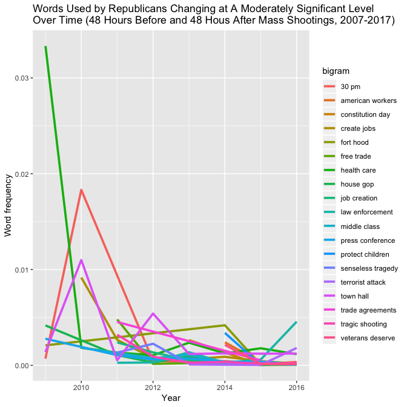

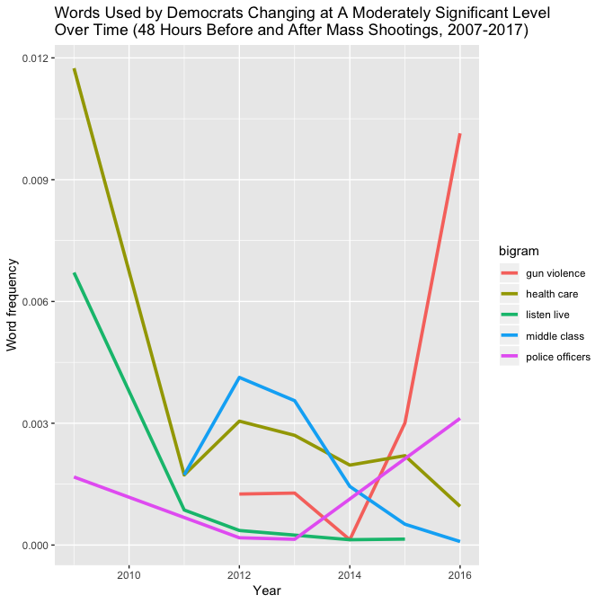

# Building a dtm to find association

```
## <<SimpleCorpus>>
## Metadata:  corpus specific: 1, document level (indexed): 0
## Content:  documents: 17902
```

```
## <<TermDocumentMatrix (terms: 19813, documents: 17902)>>
## Non-/sparse entries: 184359/354507967
## Sparsity           : 100%
## Maximal term length: 45
## Weighting          : term frequency (tf)
```

```
## $terror
## iranian notonec    iran sponsor
##    0.34    0.30    0.21    0.20
```

```
## <<SimpleCorpus>>
## Metadata:  corpus specific: 1, document level (indexed): 0
## Content:  documents: 11679
```

```
## <<TermDocumentMatrix (terms: 15546, documents: 11679)>>
## Non-/sparse entries: 119964/181441770
## Sparsity           : 100%
## Maximal term length: 38
## Weighting          : term frequency (tf)
```

```
## $terror
## notonec sponsor   franc    nice
##    0.24    0.22    0.21    0.20
```

```
## <<SimpleCorpus>>
## Metadata:  corpus specific: 1, document level (indexed): 0
## Content:  documents: 10718
```

```
## <<TermDocumentMatrix (terms: 13466, documents: 10718)>>
## Non-/sparse entries: 108303/144220285
## Sparsity           : 100%
## Maximal term length: 32
## Weighting          : term frequency (tf)
```

Words correlated with the word terror at r>0.2 among Republicans after shootings

|  | r |
| --- | --- |
| iranian | 0.38 |
| notonec | 0.33 |
| sponsor | 0.25 |
| iran | 0.24 |
| victim | 0.22 |
| repmeehan | 0.22 |
| justic | 0.21 |
| statesponsor | 0.21 |

<sup>1</sup> Footnote1; notonec refers to the hashtag NotOneCent. The hashtag was used during Iran nuclear negotions  
by those who opposed unfreezing Iran’s assetts.

```
## <<SimpleCorpus>>
## Metadata:  corpus specific: 1, document level (indexed): 0
## Content:  documents: 7184
```

```
## <<TermDocumentMatrix (terms: 11467, documents: 7184)>>
## Non-/sparse entries: 76056/82302872
## Sparsity           : 100%
## Maximal term length: 45
## Weighting          : term frequency (tf)
```

Words correlated with the word terror at r>0.2 among Democrats after shootings

|  | r |
| --- | --- |
| impuls | 0.26 |
| hate | 0.22 |

```
## <<SimpleCorpus>>
## Metadata:  corpus specific: 1, document level (indexed): 0
## Content:  documents: 7342
```

```
## <<TermDocumentMatrix (terms: 11027, documents: 7342)>>
## Non-/sparse entries: 74195/80886039
## Sparsity           : 100%
## Maximal term length: 33
## Weighting          : term frequency (tf)
```

Words correlated with the word terror at r>0.2 among Republicans before shootings

|  | r |
| --- | --- |
| sponsor | 0.27 |
| notonec | 0.26 |
| franc | 0.23 |
| attack | 0.22 |

<sup>1</sup> Footnote1; franc refers to terrorist attack in Nice, France. The attack occured on July 14,2016 exactly 48 hours before the Bouton Rouge Mass Shooting in the U.S.

<sup>2</sup> Footnote2; notonec refers to the hashtag NotOneCent. The hashtag was used during Iran nuclear negotions by those who opposed unfreezing Iran’s assetts.

```
## <<SimpleCorpus>>
## Metadata:  corpus specific: 1, document level (indexed): 0
## Content:  documents: 4337
```

```
## <<TermDocumentMatrix (terms: 8613, documents: 4337)>>
## Non-/sparse entries: 45769/37308812
## Sparsity           : 100%
## Maximal term length: 38
## Weighting          : term frequency (tf)
```

Words correlated with the word terror at r>0.2 among Democrats before shootings

|  | r |
| --- | --- |
| nice | 0.31 |
| prevail | 0.27 |
| dispos | 0.27 |
| intnl | 0.27 |
| hostil | 0.27 |
| houthi | 0.27 |
| rebel | 0.27 |
| unrel | 0.27 |
| yemen | 0.27 |
| shaken | 0.27 |
| dozen | 0.27 |
| wfranc | 0.27 |
| percept | 0.27 |
| pivot | 0.27 |
| rcdefens | 0.27 |
| suggest | 0.27 |
| appal | 0.27 |
| providersclin | 0.27 |
| threatsact | 0.27 |

<sup>1</sup> Footnote1; nice refers to terrorist attack in Nice, France. The attack occured on July 14,2016 exactly 48 hours before the Bouton Rouge Mass Shooting in the U.S.

# Sentiment Analysis

Need my tokens to be words instead of bigrams for sentiment analysis. So i change my tokens to words first

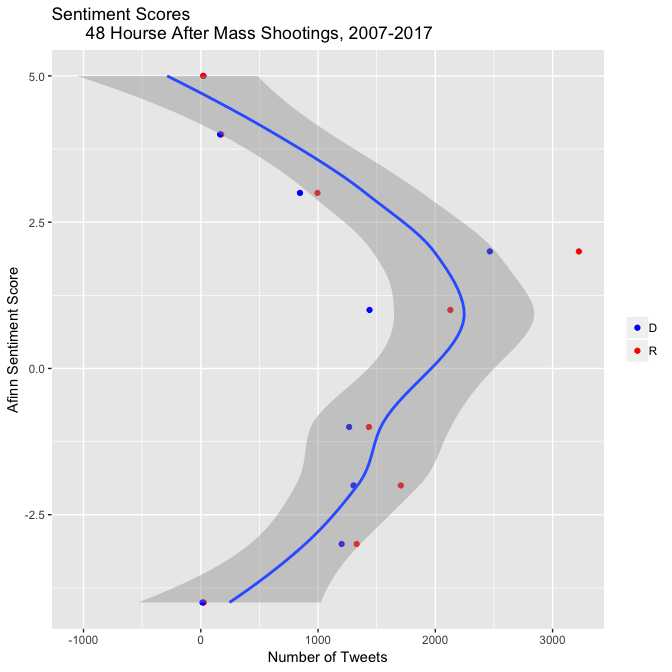

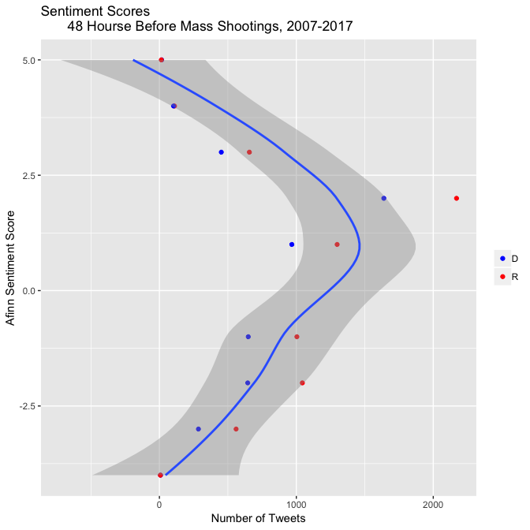

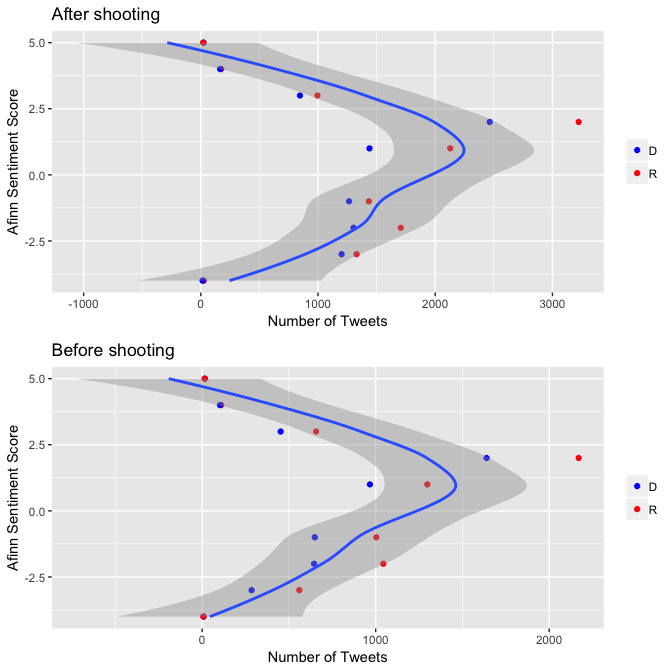